# Briefing DV capstone

2022-08-01

File ini berisi template untuk mejawab pertanyaan 5W+1H saat briefing Capstone Data Visualization sebagai langkah awal sebelum membuat Dashboard. Silakan Bapak/Ibu mengisi jawaban di bawah.

File ini tidak akan dinilai namun Bapak/Ibu **WAJIB** disubmit ke dalam classroom pada hari H briefing Capstone Data Visualization.

```r
happiness <- read.csv("world-happiness-report-2021.csv")
head(happiness)
```

|  | Country.name | Regional.indicator | Ladder.score | Standard.error.of.ladder.score | upperwhisker | lowerwhisker | Logged.GDP.per.capita | Social.support | Healthy.life.expectancy | Freedom.to.make.life.choices | Generosity | Perceptions.of.corruption | Ladder.score.in.Dystopia | Explained.by..Log.GDP.per.capita | Explained.by..Social.support | Explained.by..Healthy.life.expectancy | Explained.by..Freedom.to.make.life.choices | Explained.by..Generosity | Explained.by..Perceptions.of.corruption | Dystopia...residual |
| --- | --- | --- | --- | --- | --- | --- | --- | --- | --- | --- | --- | --- | --- | --- | --- | --- | --- | --- | --- | --- |
| 1 | Finland | Western Europe | 7.842 | 0.032 | 7.904 | 7.780 | 10.775 | 0.954 | 72.0 | 0.949 | -0.098 | 0.186 | 2.43 | 1.446 | 1.106 | 0.741 | 0.691 | 0.124 | 0.481 | 3.253 |
| 2 | Denmark | Western Europe | 7.620 | 0.035 | 7.687 | 7.552 | 10.933 | 0.954 | 72.7 | 0.946 | 0.030 | 0.179 | 2.43 | 1.502 | 1.108 | 0.763 | 0.686 | 0.208 | 0.485 | 2.868 |
| 3 | Switzerland | Western Europe | 7.571 | 0.036 | 7.643 | 7.500 | 11.117 | 0.942 | 74.4 | 0.919 | 0.025 | 0.292 | 2.43 | 1.566 | 1.079 | 0.816 | 0.653 | 0.204 | 0.413 | 2.839 |
| 4 | Iceland | Western Europe | 7.554 | 0.059 | 7.670 | 7.438 | 10.878 | 0.983 | 73.0 | 0.955 | 0.160 | 0.673 | 2.43 | 1.482 | 1.172 | 0.772 | 0.698 | 0.293 | 0.170 | 2.967 |
| 5 | Netherlands | Western Europe | 7.464 | 0.027 | 7.518 | 7.410 | 10.932 | 0.942 | 72.4 | 0.913 | 0.175 | 0.338 | 2.43 | 1.501 | 1.079 | 0.753 | 0.647 | 0.302 | 0.384 | 2.798 |
| 6 | Norway | Western Europe | 7.392 | 0.035 | 7.462 | 7.323 | 11.053 | 0.954 | 73.3 | 0.960 | 0.093 | 0.270 | 2.43 | 1.543 | 1.108 | 0.782 | 0.703 | 0.249 | 0.427 | 2.580 |

```r
names(happiness)
```

```
##  [1] "Country.name"
##  [2] "Regional.indicator"
##  [3] "Ladder.score"
##  [4] "Standard.error.of.ladder.score"
##  [5] "upperwhisker"
##  [6] "lowerwhisker"
##  [7] "Logged.GDP.per.capita"
##  [8] "Social.support"
##  [9] "Healthy.life.expectancy"
## [10] "Freedom.to.make.life.choices"
## [11] "Generosity"
## [12] "Perceptions.of.corruption"
## [13] "Ladder.score.in.Dystopia"
## [14] "Explained.by..Log.GDP.per.capita"
## [15] "Explained.by..Social.support"
## [16] "Explained.by..Healthy.life.expectancy"
## [17] "Explained.by..Freedom.to.make.life.choices"
## [18] "Explained.by..Generosity"
## [19] "Explained.by..Perceptions.of.corruption"
## [20] "Dystopia...residual"
```

# What

Saya mau menunjukkan bagian dunia manakah yang mempunyai tingkat kebahagiaan tinggi dan rendah. Membuktikan bahwa pernyataan “uang tidak membuat Anda bahagia” itu salah. Mendapatkan konklusi beberapa faktor yang menyebabkan kebahagiaan, yang menyebabkan ketidakbahagiaan, dan yang tidak berpengaruh sama sekali. Bagaimana menciptakan negara buatan yang mempunyai tingkat kebahagiaan tertinggi (dengan menambah dan mengurangi faktor apa).

**Jawab**

Tujuan yang ingin dicapai atau informasi yang ingin disampaikan:

- Apa yang membuat sebuah negara bahagia/tidak bahagia
- Menunjukkan bagian dunia manakah yang mempunyai tingkat kebahagiaan tinggi dan rendah
- Membuktikan bahwa pernyataan “uang tidak membuat Anda bahagia” itu salah
- Bagaimana menciptakan negara buatan yang mempunyai tingkat kebahagiaan tertinggi
- Membandingkan tingkat kebahagiaan negara yang menganut kapitalisme vs komunisme/sosialisme

# Who

Untuk siapa dashboard ini dibuat? Siapa target pembaca dari dashboard ini?

**Jawab**

Analisis ini lebih fokus kepada pemerintah/pejabat negara yang ingin mengarahkan negaranya menuju utopia, namun bisa juga untuk masyarakat awam yang ingin mendapatkan kualitas hidup yang lebih baik.

# Why

Apakah data yang dibuat relevan atau sesuai dengan tujuan? Mengapa?

**Jawab**

Data ini sangat cocok untuk menjawab pertanyaan pemerintahan karena kolom-kolomnya bersifat makro seperti GDP, life expectancy, dan social support.

# When

Apakah data yang digunakan masih *up to date* atau masih relevan dengan kondisi sekarang? Apakah ada informasi tentang tanggal update terakhir dari data tersebut?

**Jawab**

Data ini adalah data yang dikumpulkan tahun lalu sehingga merupakan data yang cukup relevan. Data ini saya ambil dari website Kaggle https://www.kaggle.com/datasets/ajaypalsinghlo/world-happiness-report-2021/code?datasetId=1222432&sortBy=voteCount dan merupakan salah satu data yang cukup populer karena sudah ada banyak tanggapan, diskusi, bahkan analisis.

# How

Bagaimana Bapak/Ibu menggunakan visualisasi untuk menjawab tujuan yang telah disebutkan?

Buat plot yang akan dimasukkan ke dalam dashboard. Boleh dalam bentuk `ggplot` maupun `plotly`.

**Jawab**

## Plot untuk menjawab tujuan pertama: Menunjukkan top5 negara dengan tingkat kebahagiaan tertinggi dan terendah

```r
library(dplyr)
```

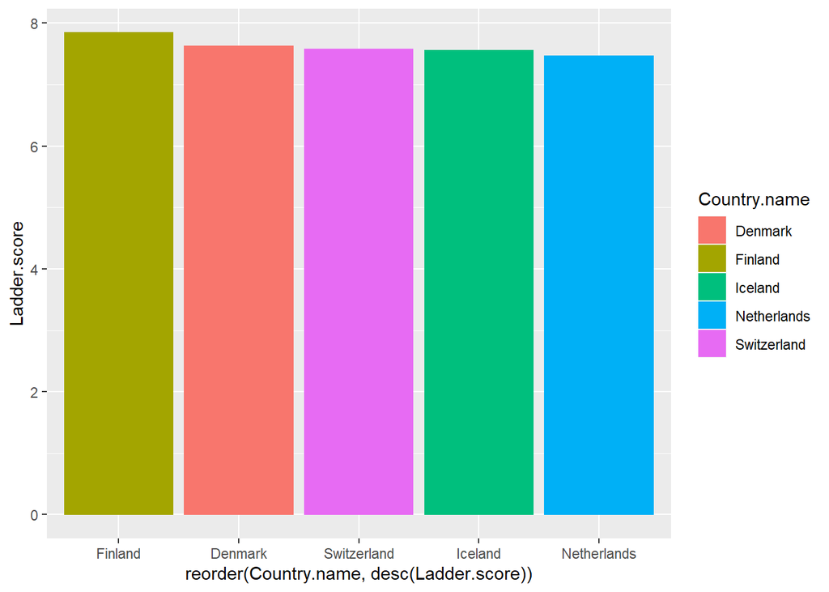

```r
library(ggplot2)
happiness_sorted <- happiness %>%
  arrange(desc(Ladder.score))

ggplot(head(happiness_sorted, 5), mapping=aes(x=reorder(Country.name, desc(Ladder.score)), y=Ladder.score))+
  geom_col(aes(col=Country.name, fill=Country.name))
```

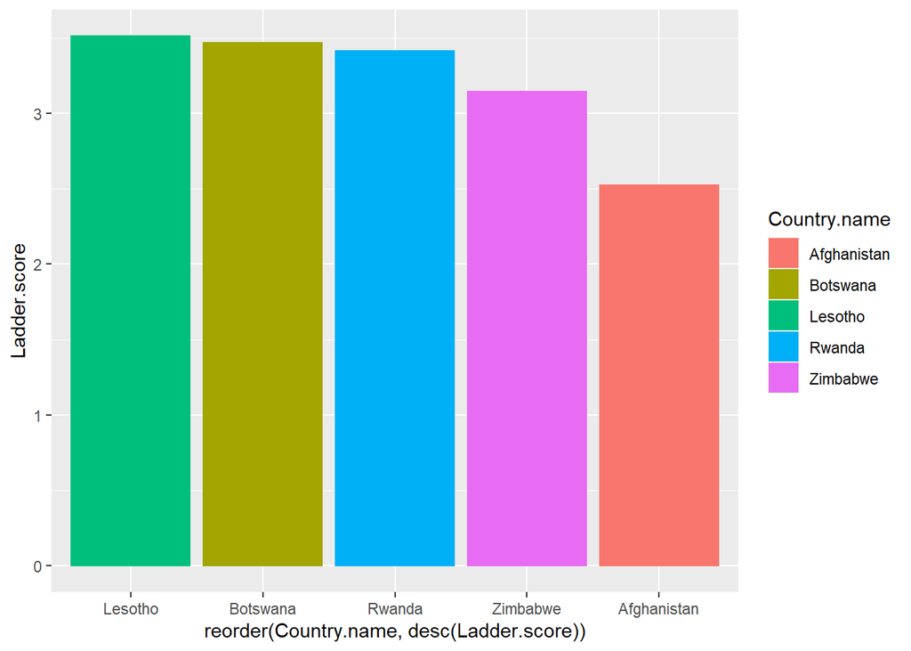

```r
ggplot(tail(happiness_sorted, 5), mapping=aes(x=reorder(Country.name, desc(Ladder.score)), y=Ladder.score))+
  geom_col(aes(col=Country.name, fill=Country.name))
```

Note for future self: Pilih warna yang lebih bagus

## Plot kedua: Menunjukkan korelasi faktor faktor yang menyebabkan kebahagiaan

```r
# your code here
library(reshape)
happiness_numeric <- happiness %>%
  select_if(is.numeric) %>%
  select(-c(Standard.error.of.ladder.score, upperwhisker, lowerwhisker))




happiness_corr <- data.frame(cor(happiness_numeric))
```

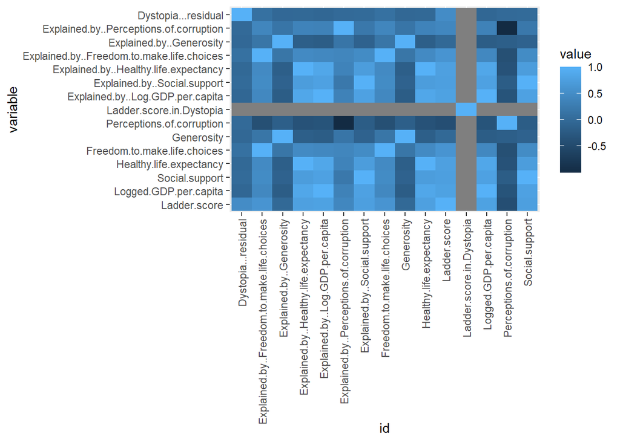

```r
happiness_corr$id <- row.names(happiness_corr)
happiness_corr <- melt(happiness_corr, id.vars="id")

ggplot(happiness_corr, mapping=aes(id, variable, fill=value))+
  geom_tile()+
  theme(axis.text.x = element_text(angle = 90, vjust = 0.5, hjust=1))
```

Note for future self: Heatmap bewarna abu mungkin karena ada data yang null (butuh data cleansing terlebih dahulu), grafik penyok (perlu diperbaiki)

## Plot ketiga: Membuktikan bahwa ungkapan “Uang tidak membuat bahagia” itu salah

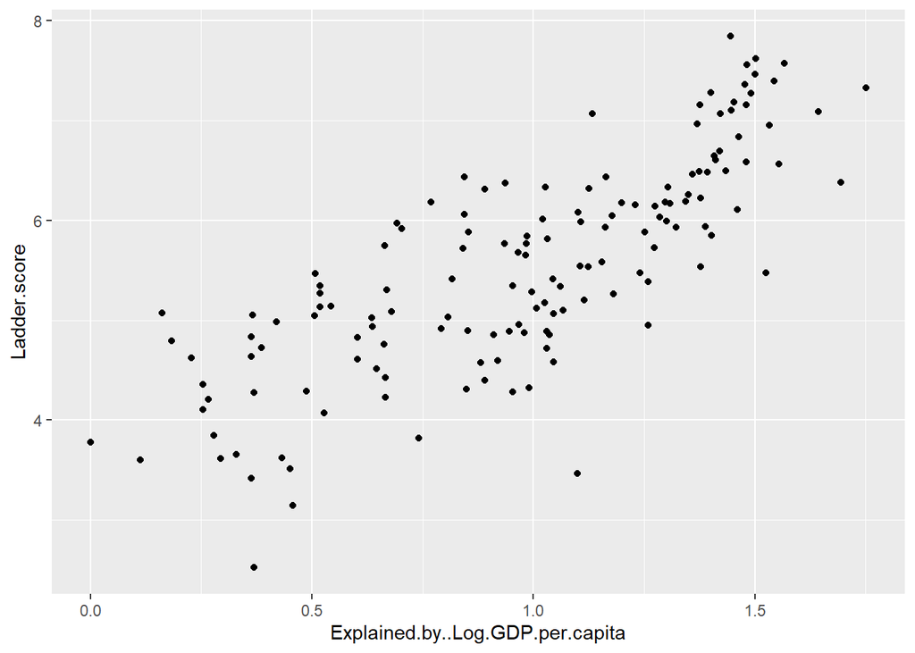

```r
# your code here
ggplot(happiness, mapping=aes(x=Explained.by..Log.GDP.per.capita, y=Ladder.score))+
  geom_point()
```

Note for future self: Boleh tambah garis korelasi

## Plot keempat: Menunjukkan perbandingan tingkat kebahagiaan negara kapitalis vs komunis/sosialis

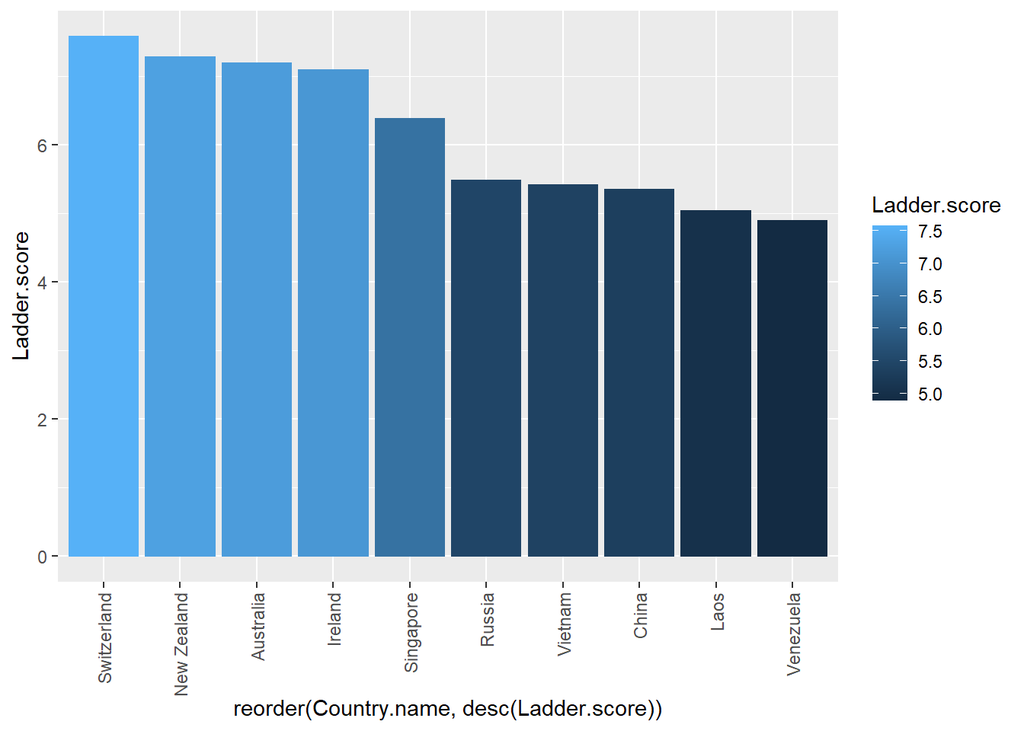

```r
happiness_cap <- happiness %>%
  filter(Country.name %in% c("Singapore", "New Zealand", "Australia", "Switzerland", "Ireland"))

happiness_sos <-happiness %>%
  filter(Country.name %in% c("China", "Venezuela", "Russia", "Vietnam", "Laos"))


ggplot(rbind(happiness_cap, happiness_sos), mapping=aes(reorder(Country.name, desc(Ladder.score)), Ladder.score))+
  geom_col(aes(col=Ladder.score, fill=Ladder.score))+
  theme(axis.text.x = element_text(angle = 90, vjust = 0.5, hjust=1))
```

Note for future self: Bisa bikin pembatas antara negara kapitalis vs sosialis (warna bagusnya).

# Where

Bagaimana desain layout atau tata letak dashboard yang akan dibuat?

**Jawab**

Contoh penulisan layout.

Tab atau halaman pertama

- Barchart top5 negara paling bahagia
- Barchart top5 negara paling tidak bahagia
- Heatmap korelasi tingkat kebahagiaan dan faktor-faktornya
- Tingkat kebahagiaan negara kapitalis vs negara komunis

Tab atau halaman kedua

- selectInput untuk menentukan region mana yang mau di-inspek
- Dengan leaflet menunjukkan peta dan tingkat kebahagiannya

Tab tiga

- Raw dataset